# RTMB Course

Paul van Dam-Bates

## Introductions

- Paul van Dam-Bates (Fisheries and Oceans Canada)
- PhD Statistics University of St Andrews (Scotland)
- NIMBLE Development Team [here](https://r-nimble.org/)
- Work on computational statistics (e.g. approximate posterior distributions, MCMC methods, efficient matrix exponentiation, and other things)
- R packages `nimbleQuad` and `spbal`

## Why RTMB

- R wrapper for TMB
- Convert R code to C++ for speed
- Automatic Differentiation
- Integrate out random effects (e.g. Laplace)
- Code can run in basic R for checking

## Course Structure

- Can’t code if you don’t understand model
- Focus on understanding a model, then coding it in R
- RTMB is very simple if you know how to code likelihoods in R
- Will focus on understanding in the mornings and practical coding in the afternoon

## Learning Outcomes

- Understand how to fit a custom likelihood and report on it
- Basic programming in RTMB
- Fitting hierarchical models
- RTMB specific applications

## Outline Day 1

1. (9:00 – 9:50) Welcome and course introduction, introduction to maximum likelihood estimation.
2. (10:00 - 10:50) Writing and fitting a stock recruit likelihood in R. Improve that likelihood with RTMB and compare. Compare with standard R packages.
3. (11:00 – 11:50) Introduction to RTMB and automatic differentiation (AD). Compare AD with finite differencing. What is a gradient and a Hessian.
4. (13:00 – 13:50) Add random effects to your likelihood. Laplace and RTMB
5. (14:00 – 14:50) Practice writing likelihoods with random effects and fit them. Hierarchical stock recruitment models. Compare output with `glmmTMB`.
6. (15:00 – 16:00) Additional random effect structures (e.g. time varying productivity).

## Outline Day 2

1. (9:00 – 9:50) Variance estimation for maximum likelihood. Delta method to approximate parameters. Using RTMB to report variance and confidence intervals.
2. (10:00 – 10:50) RTMB functionality. Learn little details about how to use RTMB effectively.
3. (11:00 – 11:50) Writing helper functions and atomics (e.g. Lambert W). Best coding practices.
4. (13:00 – 16:00) Practice writing complex likelihood functions in RTMB

## Probability Functions

- Random variable $x$
- Probability mass function $p(x)$ if $x$ is discrete

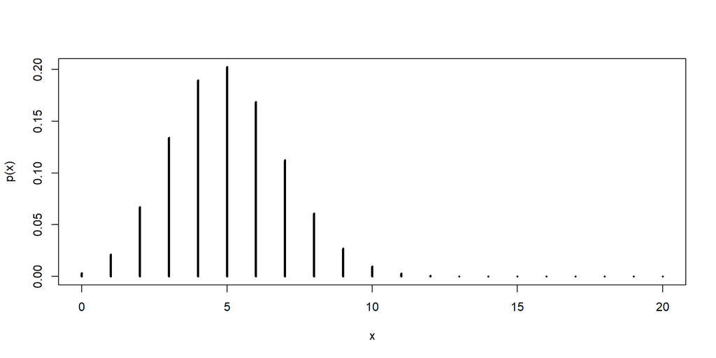

- Probability density function $f(x)$ if $x$ is continuous.
- $f(x)$ describes a density, not a probability of an event.
- Probability defined by some area under the curve, e.g.
  $$p(x \leq 1)= \int_{-\infty}^1 f(x)dx$$

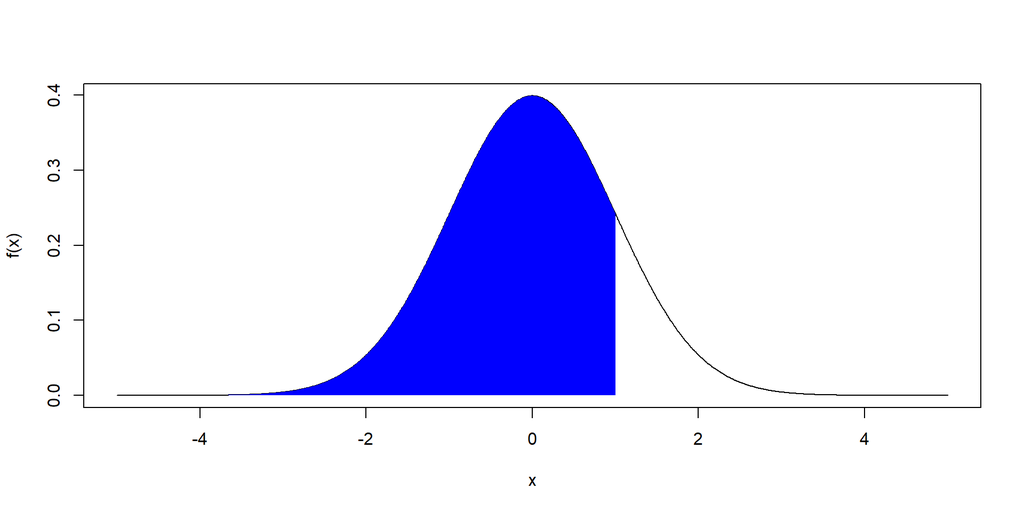

## Expectation

- Expected value of $x$ (or mean) when discrete
  $$\mathbb{E}(x) = \sum xp(x)$$

```r
  mean(rbinom(10000, size = 10, prob = 0.25))
```

```
[1] 2.5045
```

```r
  sum((0:10)*dbinom(0:10, size = 10, prob = 0.25))
```

```
[1] 2.5
```

- Expected value of $x$ (or mean) when continuous
  $$\mathbb{E}(x) = \int xf(x)dx$$

```r
  mean(rgamma(10000, 1, 2))
```

```
[1] 0.4949177
```

```r
  integrate(\(x){x*dgamma(x,1,2)}, lower=0, upper=Inf)$value
```

```
[1] 0.5
```

- Sample mean
  $$\mathbb{E}(x) = \frac{\sum x_i}{n}$$

## Variance

- Definition of variance is difference of squared expectation and expectation squared.
  $$Var(x) = \mathbb{E}(x^2) - \mathbb{E}(x)^2.$$

```r
  var(rgamma(10000, 1, 2))
```

```
[1] 0.2469567
```

```r
  integrate(\(x){x^2*dgamma(x,1,2)}, lower=0, upper=Inf)$value - (1/2)^2
```

```
[1] 0.25
```

- Sample variance
  $$Var(x) = \frac{(\sum x_i - \bar{x})^2}{n-1}$$

## Joint Density

- Some sample $\textbf{x}$, of size $n$
- Assume $x_i \sim N(\mu, \sigma)$ and all are independent.
- Then the joint density is
  $$f(\textbf{x}) = f(x_1, \ldots, f_n) = f(x_1)f(x_2) \cdots f(x_n) = \prod_{i=1}^n f(x_i)$$

## Conditional Density

- Some sample $\textbf{x}$, of size $n$
- Assume $x_i|u \sim N(u + \mu, \sigma)$
- $u \sim N(0, 1)$ is a random variable (e.g. random effect)
- The $x$ values are not independent!
  $$f(\textbf{x}) \neq \prod_{i=1}^n f(x_i)$$
- However, conditional on the value of $u$, they are independent,
  $$f(\textbf{x}|u) = \prod_{i=1}^n f(x_i|u)$$
- Joint density can be written as
  $$f(\textbf{x}) = \int f(\textbf{x},u)du = \int f(\textbf{x}|u)f(u)du$$

## Likelihood

- For some parameters $\mathbf{\theta} = \{\mu, \sigma\}$
- Likelihood is the data joint density expressed in terms of the parameters, conditional on the data.
- $L(\mathbf{\theta} | \textbf{x}) = \prod_{i=1}^n f(x_i)$
- Maximum likelihood estimation – Find maximum values of parameters given the data.

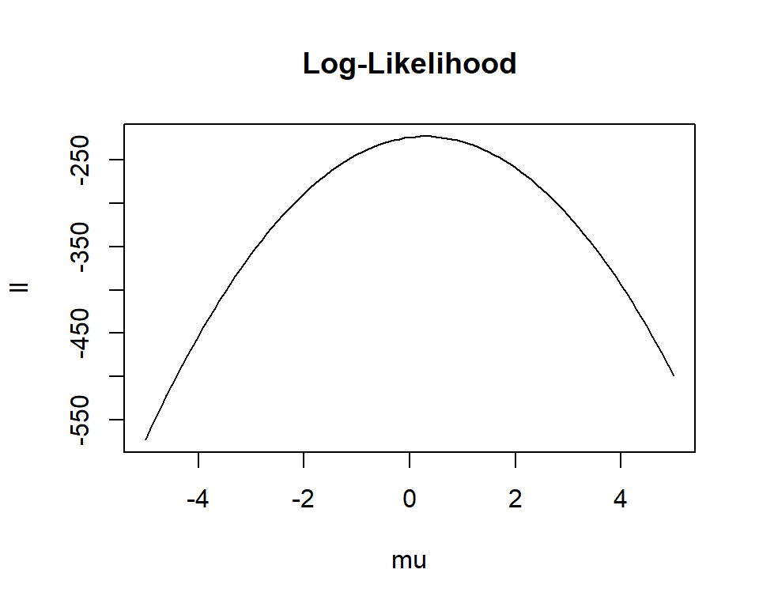

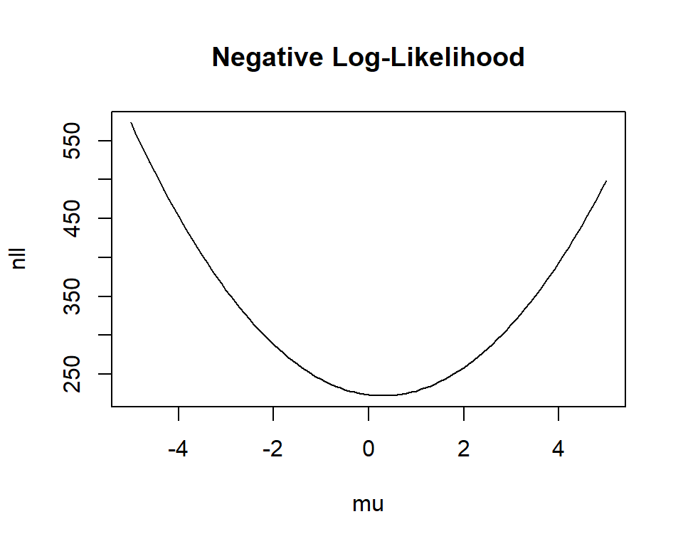

## Optimization in R

- Gradient is the slope (derivative) in terms of the parameters
- Gradient based methods optimization uses slope to find max/min
- Random start, evaluate objective function, use gradient to move to new value
- Run until at maximum/minimum (where gradient is zero)
- Examples are `optim` or `nlminb`
- If gradient not provided, then finite differences are used.

```r
set.seed(24)
x <- rnorm(100, 0.25, 2)
nll <- \(pars){
  mu <- pars[1]
  sigma <- exp(pars[2])
  -sum(dnorm(x, mu, sigma, log = TRUE))
}

optim(c(0,0), nll)
```

```
$par
[1] 0.002630714 0.634894835

$value
[1] 205.3885

$counts
function gradient
      57       NA

$convergence
[1] 0

$message
NULL
```

```r
# nlminb(c(0,0), nll)
```

## Optimization in R

- What about more than one peak? (Multimodality)
- Derivative is zero at more than one place
- Want ‘global’ maximum

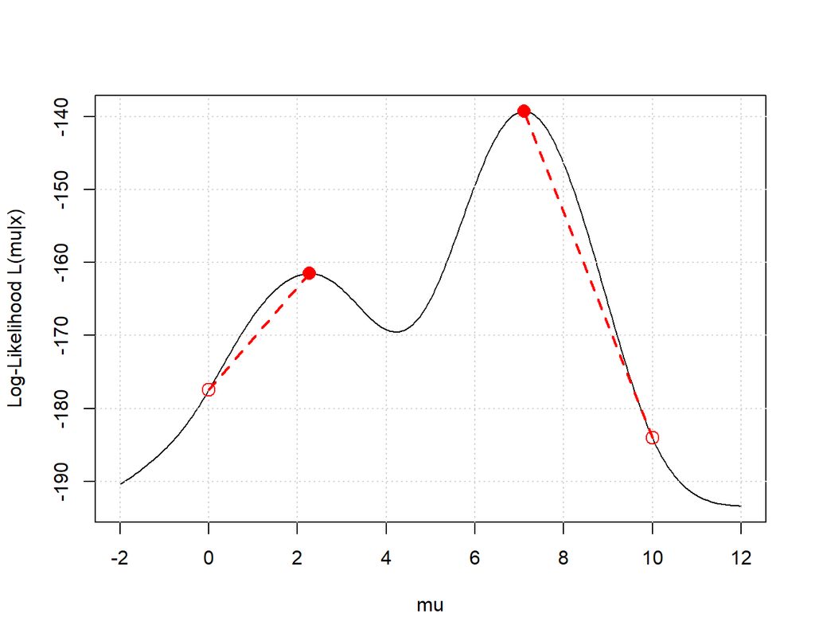